# Travel Mode Prediction for Sustainable Transport Planning

2025-10-27

## Problem Statement

**Objective:** Predict travel mode choice on the Gold Coast using household survey data

**Task:** Multi-class classification

- Vehicle Driver / Passenger
- Public Transport (Train, Bus, Ferry)
- Active Transport (Walking, Bicycle)

**Why it matters:**

- Support sustainable transport planning
- Inform infrastructure investment decisions
- Enable targeted policy interventions

## Initial Dataset

Dataset Overview

- Source: 2015 Gold Coast Survey
- Size: 22,587 observations
- Variables: 179 → 163

Key Challenges Identified

- Missing values: Up to 99%
- Class imbalance: 80%+ vehicle
- Outliers: 20+ variables >1%
- Data leakage: Vehicle attributes

## Exploratory Data Analysis

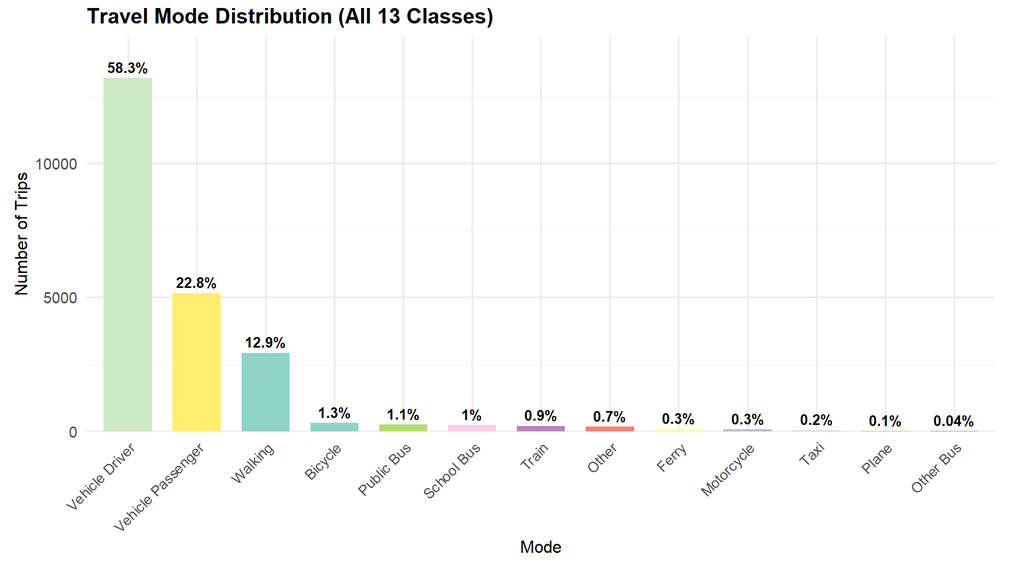

**Key Finding:** Severe class imbalance - dominant vehicle usage requires careful handling

## EDA: Feature-Target Correlation

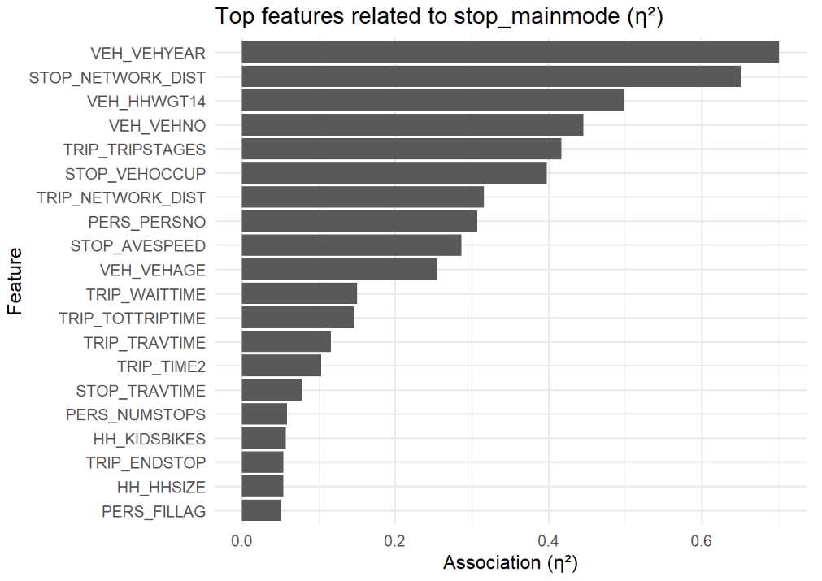

**Finding:** Vehicle features (VEH_VEHYEAR, STOP_NETWORK_DIST) show strongest correlation with travel mode

## EDA: Categorical Features

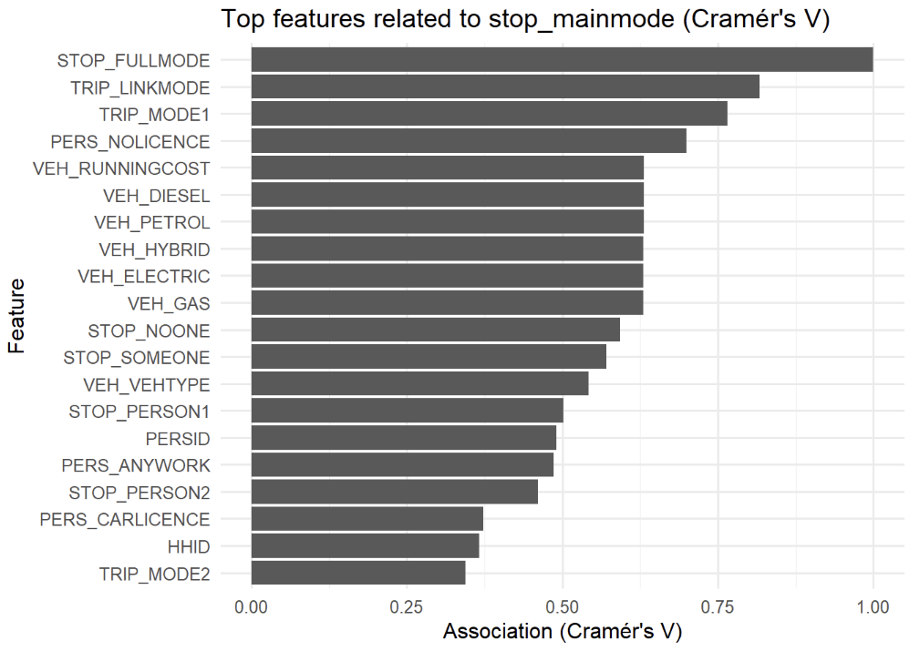

**Finding:** STOP_FULLMODE, VEH_RUNNINGCOST, PERS_NOLICENCE strongly associated with mode choice

## EDA: Feature Collinearity

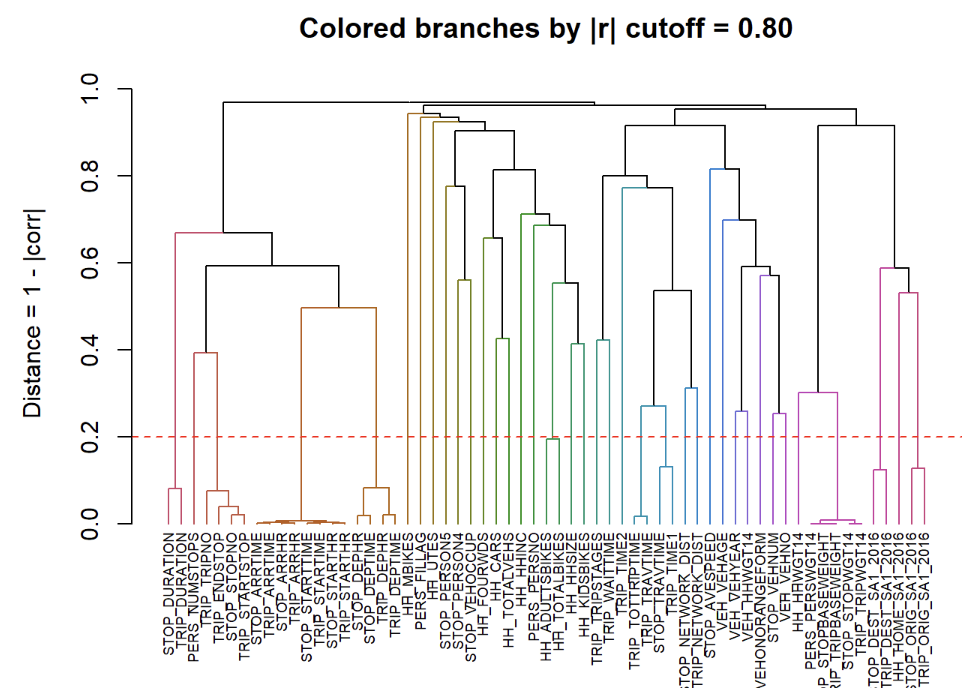

## Key Findings from EDA

**Top Predictive Features (from EDA)**

- **Numerical (η²):** Vehicle characteristics dominated
  - `VEH_VEHYEAR`, `STOP_NETWORK_DIST`, `VEH_HHWGT14`
- **Categorical (Cramér’s V):** Strong associations found
  - `STOP_FULLMODE` (1.0 - data leakage!)
  - `PERS_NOLICENCE`, `VEH_RUNNINGCOST`

**Key Insight:** Vehicle proxies dominated predictions → Need to remove for real-world applicability

## Feature Selection & Engineering

EDA Insight: Vehicle attributes dominated predictions - these are direct proxies that reveal the answer

Our Approach:

- VEH_PER_PERSON, VEH_PER_ADULT (household vehicle availability)
- TRIP_SPEED, TIME_PERIOD, IS_WEEKEND (trip timing characteristics)
- DIST_CATEGORY, HAS_LICENSE_AND_CAR (travel capability indicators)

## Feature Selection & Engineering: Visual Summary

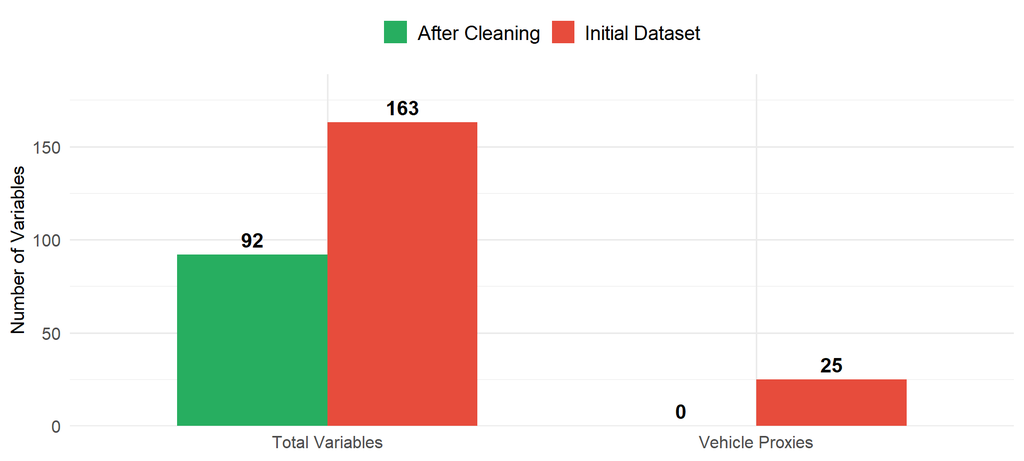

Key Distinction: Kept `HH_CARS` (availability) ✓ | Removed `VEH_VEHTYPE` (usage) ✗

## Model Selection

Selected Models: Random Forest, XGBoost, GLM-NET, SVM, Decision Tree

Why These 5 Models?

- **Diverse Approaches:** Tree-based (RF, XGBoost, DT), Linear (GLM-NET), Kernel-based (SVM)
- **Handle Class Imbalance:** All support class weighting or rebalancing techniques
- **Interpretability vs Performance:** From simple (Decision Tree) to complex (XGBoost)
- **Industry Standard:** Widely used for multi-class classification in transport research

## Experimental Setup & Evaluation Metrics

- **Dataset:** 22,587 trips, 92 features, 13 travel modes
- **Train/Test Split:** 80/20 ratio with stratified sampling
- **Cross-Validation:** 5-fold CV, stratified by target class
- **Optimization Metric:** Macro-F1 score

Evaluation Metrics

- **Accuracy:** Overall correct predictions
- **Macro-Precision:** Average precision across all modes (equal weight per class)
- **Macro-Recall:** Average recall across all modes (equal weight per class)
- **Macro-F1:** Harmonic mean of Macro-Precision and Macro-Recall

**Why Macro-averaging?** Equal weight to all modes, preventing 80%+ vehicle class dominance.

## Model Implementation: Preprocessing Strategy

- **Random Forest:** Native categorical handling (no encoding needed)
- **XGBoost:** Mixed encoding for efficiency
  - High cardinality (>50 levels): Target encoding
  - Low cardinality (≤50 levels): One-hot encoding
- **Decision Tree:** One-hot encoding (required for high-cardinality features)
- **GLM-NET & SVM:** One-hot encoding + scaling (required for numeric operations)

**Data Leakage Prevention:** All encoders/scalers fitted within each CV fold (never on full data).

## Model Implementation: Hyperparameter Optimization

- **Random Forest:** Grid search (mtry, min_n, trees) with class weighting
- **XGBoost:** Gradient boosting with Bayesian optimization (22 iterations)
- **GLM-NET:** Elastic net regularization with Bayesian optimization
- **SVM:** RBF kernel with Grid search (cost, gamma)
- **Decision Tree:** Bayesian optimization (22 iterations) with complexity tuning

**Optimization Approach:** All models use 5-fold cross-validation to find hyperparameters that maximize Macro-F1 score

**Data Leakage Prevention:** Class weights calculated within each CV fold (never on full training data).

## Model Evaluation: Performance Comparison

Metric focus: Macro-F1 due to class imbalance (accuracy can be inflated).

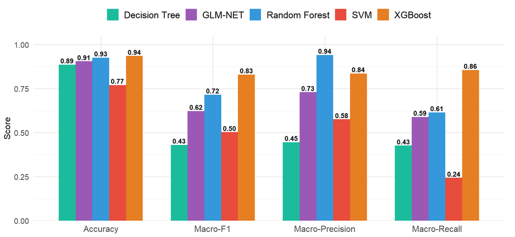

Key Insight: XGBoost (orange) best overall balance; Random Forest (blue) highest Macro-Precision

## Best Model Selected: XGBoost

Optimization

- **Hyperparameter tuning:** Bayesian optimization with 5-fold CV to maximize Macro-F1 (see Appendix for details)

Key Findings

- **Balanced performance:** Macro-Precision 0.84 & Macro-Recall 0.86 → Macro-F1 0.83
- **Minority modes:** Remain challenging due to tiny sample sizes; balanced performance still best among models
- **Generalization:** Test Macro-F1 0.83 > CV Macro-F1 0.76
- **Top features:** Distance (9.1%), speed competitiveness (7.0%), station access (5.7%)

## Conclusion

**Key Takeaways:**

- **Imbalance is manageable:** Weighting + Macro-F1
- **Modeling choice matters:** Boosting gave the best balanced performance
- **Policy signal:** Distance, speed competitiveness, and station access drive mode choice

These findings confirm that our model can predict travelers’ transport modes with reliable accuracy, supporting its use in transport planning and policy evaluation.

**Impact:** Feature importance reveals actionable patterns for targeted policy interventions:

- **Distance-based transit:** Top predictor (9.1%) → Optimize service for specific trip lengths
- **Speed competitiveness:** Critical factor (7.0%) → Ensure transit is time-competitive
- **Transit-oriented planning:** Infrastructure access matters (5.7%) → Focus improvements near stations

## Limitations & Future Directions

Limitations

- **Insufficient data for rare modes:** Ferry (79 trips), Plane (13 trips), Other Bus (8 trips) - models struggle with <0.3% sample sizes
- **Deployment focus:** Prioritize major modes (Vehicle, Walking, Bus, Train) for reliable policy decisions

Future Directions

*Next Steps for Deployment:*

- **Geographic targeting:** Identify suburbs with high mode-shift potential
- **Scenario analysis:** Test interventions (faster buses, new routes) using model predictions
- **Real-world partnership:** Collaborate with Gold Coast transport authority

*Model Enhancements:*

- Collect more data for rare modes; incorporate temporal patterns; integrate real-time factors

## Questions & Discussion

Thank You!

Any Questions?

## Appendix: Optimized Hyperparameters

**XGBoost (Best: Macro-F1 = 0.83)** - `max_depth`: 7, `eta`: 0.31, `subsample`: 1.00, `colsample_bytree`: 0.83, `min_child_weight`: 1.0, `gamma`: 0.00

**Random Forest (Best: Macro-F1 = 0.72)** - `mtry`: 18, `min_n`: 2, `trees`: 600

**GLM-NET (Best: Macro-F1 = 0.62)** - `penalty`: 0.000013, `mixture`: 0.36 (more L2 regularization)

**SVM (Best: Macro-F1 = 0.50)** - `cost`: 4.00, `gamma`: 0.050, CV Macro-F1: 0.27 (±0.01)

**Decision Tree (Best: Macro-F1 = 0.43)** - `cp`: 0.0001, `max_depth`: 22, `min_split`: 10, `min_bucket`: 25

**Note:** All models used 5-fold cross-validation for hyperparameter tuning